# **Proyecto Business Performance Analysis**

Jose Alejandro Miranda, Maria Jesus Palero, Jaime Andres Salazar y Paola Rita Villar.

## **1. Preparación de los datos**

Librerías a utilizar:

```r
library(tidyverse) # tidyr, dplyr, ggplot2, purrr.....
library(DescTools) #Herramientas para estadística descriptiva y análisis de datos
library(psych) #Herramientas de entrada de datos y análisis descriptivo.
library(scales) #Herramienta complemento de "ggplot2"
library (reshape2) #Herramientas de manipulación de datos
library(ggpubr) #Complemento de ggplot
library(ggplot2);theme_set(
  theme_minimal() +
    theme(legend.position = "right")) ## Tema por defecto a los gráficos
library(ggsci) #Paletas de colores para graficos
```

Durante todo el análisis se trabaja con la base de datos suministrada “`Dataset_Compradores.csv`”, la cual, para su estandarización, se extrae desde URL. Además, por indicaciones durante clase, la última variable `Exited` no se tiene en cuenta.

```r
data_ori <- read.csv("https://raw.githubusercontent.com/Lermaa2/ProjectoFinal-BPA/68c182ad59e0039875994b11acfcd40a66949acd/Dataset_Compradores.csv"
                 ,dec=".")

dat <- data_ori[2:13]; glimpse(dat);tail(dat[,1:4])
```

```
## Rows: 10,000
## Columns: 12
## $ CustomerId      <int> 15634602, 15647311, 15619304, 15701354, 15737888, 1...
## $ Surname         <chr> "Hargrave", "Hill", "Onio", "Boni", "Mitchell", "Ch...
## $ CreditScore     <int> 619, 608, 502, 699, 850, 645, 822, 376, 501, 684, 5...
## $ Geography       <chr> "France", "Spain", "France", "France", "Spain", "Sp...
## $ Gender          <chr> "Female", "Female", "Female", "Female", "Female", "...
## $ Age             <int> 42, 41, 42, 39, 43, 44, 50, 29, 44, 27, 31, 24, 34,...
## $ Tenure          <int> 2, 1, 8, 1, 2, 8, 7, 4, 4, 2, 6, 3, 10, 5, 7, 3, 1,...
## $ Balance         <dbl> 0.00, 83807.86, 159660.80, 0.00, 125510.82, 113755....
## $ NumOfProducts   <int> 1, 1, 3, 2, 1, 2, 2, 4, 2, 1, 2, 2, 2, 2, 2, 2, 1, ...
## $ HasCrCard       <int> 1, 0, 1, 0, 1, 1, 1, 1, 0, 1, 0, 1, 1, 0, 1, 0, 1, ...
## $ IsActiveMember  <int> 1, 1, 0, 0, 1, 0, 1, 0, 1, 1, 0, 0, 0, 0, 1, 1, 0, ...
## $ EstimatedSalary <dbl> 101348.88, 112542.58, 113931.57, 93826.63, 79084.10...
```

```
##       CustomerId   Surname CreditScore Geography
## 9995    15719294      Wood         800    France
## 9996    15606229  Obijiaku         771    France
## 9997    15569892 Johnstone         516    France
## 9998    15584532       Liu         709    France
## 9999    15682355 Sabbatini         772   Germany
## 10000   15628319    Walker         792    France
```

Se observa que existen 10000 entradas, no existen ni notas ni pie de páginas que puedan requerir ser eliminados antes del análisis.

## **2. Descripción de variables**

Se indica el tipo de dato/variable con el que se trabaja, agrupándolas en dos grupos:

##### **Categóricas/Cualitativas:**

- `CustomerId` : Identificación del cliente. Se transforma a factor. (`factor`/nominal).
- `Surname` : Apellido de los clientes. Se transforma a factor. (`factor`/nominal).
- `Geography` : País de origen de cada cliente. Se transforma a factor. (`factor`/nominal)
- `Gender` : Genero de cada cliente. Se transforma a factor. (`factor`/nominal)
- `HasCrCard` : Posee/ No posee (1/0) Tarjeta de Crédito. Se transforma a factor. (`factor``/nominal).
- `IsActiveMember` : Indica si el cliente esta/no está (1/0) activo en la entidad.

Todas se transforman a factor (`factor`/nominal).

##### **Cuantitativas:**

- `Age` : Edad del cliente. (`int`/discreta).
- `Tenure` : Meses restantes para el pago total de la deuda. (`int`/discreta).
- `CreditScore` : Score de Crédito, valoración de cada cliente basado en su historial crediticio. (`int`/discreta).
- `EstimatedSalary` : Salario estimado del cliente. (`num`/continua).
- `Balance` : Deuda pendiente de pago. (`num`/continua).
- `NumOfProducts` : Productos bancarios de cada cliente. (`int`discreta).

El valor `CreditScore` se usa para asignar niveles a los clientes que dependen del modelo de cada banco, pero se suele usar:

- 350 ~ 579 - `poor`
- 580 ~ 669 - `fair`
- 670 ~ 739 - `good`
- 740 ~ 799 - `very_good`
- Mayor que 800 - `excellent`

Para el análisis, se decide agregar la variable categórica `CreditCat` (`ord`/ordinal). Adicional a los cambios de clase mencionados, se busca conocer si existen valores nulos o NA:

```r
dat <-  data_ori[2:13] %>%
  mutate( CreditCat= case_when(CreditScore < 580 ~ 1,
        CreditScore >= 580 & CreditScore < 669 ~ 2,
        CreditScore >= 669 & CreditScore < 739 ~ 3,
        CreditScore >= 739 & CreditScore < 799 ~ 4,
        CreditScore >= 799 ~ 5,
        TRUE ~ 0)) %>%
  select(CustomerId,Surname,Geography,Gender,
         IsActiveMember, HasCrCard, CreditCat,
         CreditScore, Age, Balance,
         EstimatedSalary, Tenure, NumOfProducts) %>%
  mutate(across(c(CustomerId,
                  Surname,
                  Geography,
                  Gender,
                  IsActiveMember,
                  HasCrCard,
                  CreditCat),
                factor)) %>%
  rename_if(is.numeric,~paste("cu",.x,sep = "_") ) %>%
  rename_if(negate(is.numeric),~paste("ca",.x,sep = "_") )
##* Para `CreditCat`:
dat$ca_CreditCat <- factor(dat$ca_CreditCat,
                        labels = c("poor", "fair",
                                   "good", "very_good",
                                   "excellent"),ordered = T);glimpse(dat)
```

```
## Rows: 10,000
## Columns: 13
## $ ca_CustomerId      <fct> 15634602, 15647311, 15619304, 15701354, 15737888...
## $ ca_Surname         <fct> Hargrave, Hill, Onio, Boni, Mitchell, Chu, Bartl...
## $ ca_Geography       <fct> France, Spain, France, France, Spain, Spain, Fra...
## $ ca_Gender          <fct> Female, Female, Female, Female, Female, Male, Ma...
## $ ca_IsActiveMember  <fct> 1, 1, 0, 0, 1, 0, 1, 0, 1, 1, 0, 0, 0, 0, 1, 1, ...
## $ ca_HasCrCard       <fct> 1, 0, 1, 0, 1, 1, 1, 1, 0, 1, 0, 1, 1, 0, 1, 0, ...
## $ ca_CreditCat       <ord> fair, fair, poor, good, excellent, fair, excelle...
## $ cu_CreditScore     <int> 619, 608, 502, 699, 850, 645, 822, 376, 501, 684...
## $ cu_Age             <int> 42, 41, 42, 39, 43, 44, 50, 29, 44, 27, 31, 24, ...
## $ cu_Balance         <dbl> 0.00, 83807.86, 159660.80, 0.00, 125510.82, 1137...
## $ cu_EstimatedSalary <dbl> 101348.88, 112542.58, 113931.57, 93826.63, 79084...
## $ cu_Tenure          <int> 2, 1, 8, 1, 2, 8, 7, 4, 4, 2, 6, 3, 10, 5, 7, 3,...
## $ cu_NumOfProducts   <int> 1, 1, 3, 2, 1, 2, 2, 4, 2, 1, 2, 2, 2, 2, 2, 2, ...
```

```r
##* Se da formato canónico a la tabla de datos, es decir, se muestra una fila para cada valor observado (medido). Útil para futuras manipulaciones.
dat_long = melt(dat);glimpse(dat_long)
```

```
## Rows: 60,000
## Columns: 9
## $ ca_CustomerId     <fct> 15634602, 15647311, 15619304, 15701354, 15737888,...
## $ ca_Surname        <fct> Hargrave, Hill, Onio, Boni, Mitchell, Chu, Bartle...
## $ ca_Geography      <fct> France, Spain, France, France, Spain, Spain, Fran...
## $ ca_Gender         <fct> Female, Female, Female, Female, Female, Male, Mal...
## $ ca_IsActiveMember <fct> 1, 1, 0, 0, 1, 0, 1, 0, 1, 1, 0, 0, 0, 0, 1, 1, 0...
## $ ca_HasCrCard      <fct> 1, 0, 1, 0, 1, 1, 1, 1, 0, 1, 0, 1, 1, 0, 1, 0, 1...
## $ ca_CreditCat      <ord> fair, fair, poor, good, excellent, fair, excellen...
## $ variable          <fct> cu_CreditScore, cu_CreditScore, cu_CreditScore, c...
## $ value             <dbl> 619, 608, 502, 699, 850, 645, 822, 376, 501, 684,...
```

Siguiendo con las variables categóricas, para la exploración de los datos se han utilizado gráficos de barras. De esta manera, se pueden conocer los valores y frecuencias de cada una de las variables.:

```r
##* Frecuencias
dat %>%
  select(starts_with("ca") & !ca_Surname) %>%
  summary()
```

```
##   ca_CustomerId   ca_Geography   ca_Gender    ca_IsActiveMember ca_HasCrCard
##  15565701:   1   France :5014   Female:4543   0:4849            0:2945
##  15565706:   1   Germany:2509   Male  :5457   1:5151            1:7055
##  15565714:   1   Spain  :2477
##  15565779:   1
##  15565796:   1
##  15565806:   1
##  (Other) :9994
##     ca_CreditCat
##  poor     :2362
##  fair     :3295
##  good     :2437
##  very_good:1239
##  excellent: 667
##
##
```

De esta manera, se pueden conocer los valores y frecuencias de cada una de las variables categóricas. Además, cada observación/fila tiene un `CustomerId` único (es decir, datos de clientes diferentes) y en ningún caso se identifican entradas NaN.

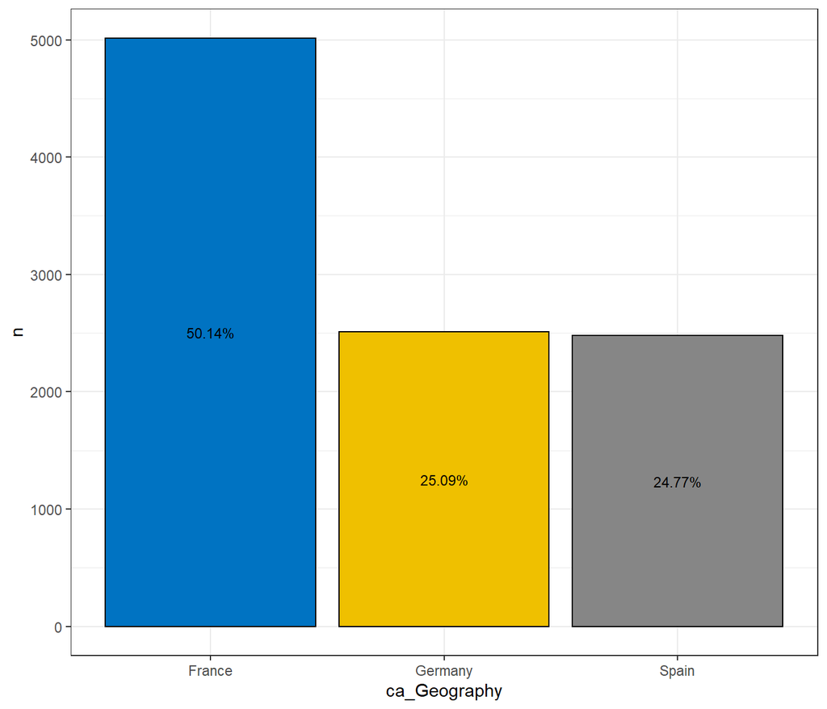

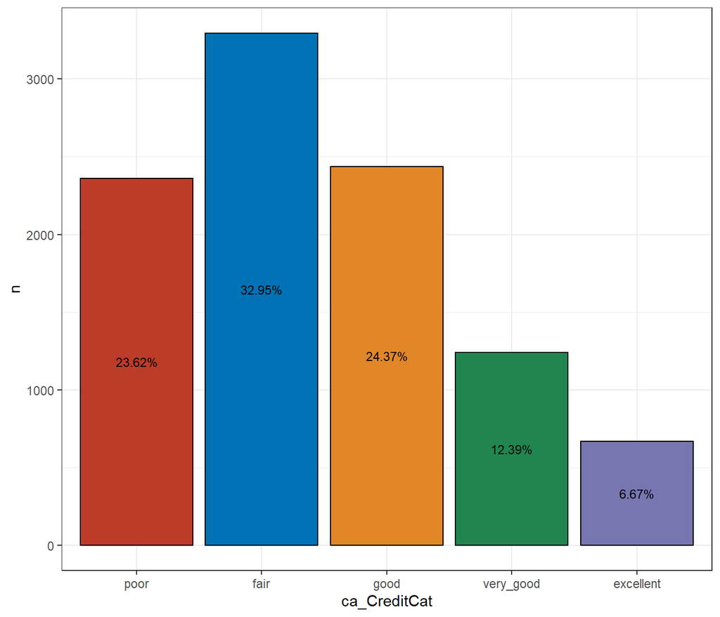

```r
##* Geography
dat %>%
  count(ca_Geography) %>%
  mutate(prop = percent(prop.table(n))) %>%
  ggplot(aes(ca_Geography,n,label= prop,fill= ca_Geography)) +
  geom_col(color="black")+
  geom_text(check_overlap = TRUE,
            position = position_stack(vjust = 0.5),
            size=3)+
  theme_bw()+
  theme(legend.position='none')+
  scale_fill_jco()

##* CreditCat
dat %>%
  count(ca_CreditCat) %>%
  mutate(prop = percent(prop.table(n))) %>%
  ggplot(aes(ca_CreditCat,n,label= prop,fill= ca_CreditCat)) +
  geom_col(color="black")+
  geom_text(check_overlap = TRUE,
            position = position_stack(vjust = 0.5),
            size=3)+
  theme_bw()+
  theme(legend.position='none')+
  scale_fill_nejm()
```

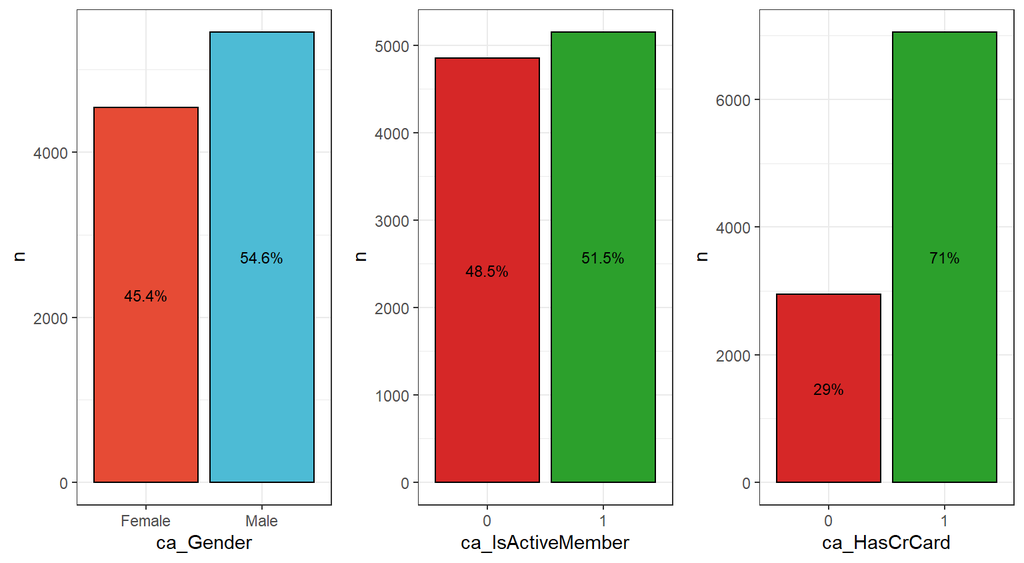

```r
##* Gender
plot_Gender <-dat %>%
  count(ca_Gender) %>%
  mutate(prop = percent(prop.table(n))) %>%
  ggplot(aes(ca_Gender,n,label= prop,fill= ca_Gender)) +
  geom_col(color="black")+
  geom_text(check_overlap = TRUE,
            position = position_stack(vjust = 0.5),
            size=3)+
  theme_bw()+
  theme(legend.position='none')+
  scale_fill_npg()

##* IsActiveMember
plot_Act <-dat %>%
  count(ca_IsActiveMember) %>%
  mutate(prop = percent(prop.table(n))) %>%
  ggplot(aes(ca_IsActiveMember,n,label= prop,
             fill=ca_IsActiveMember)) +
  geom_col(color="black")+
  geom_text(check_overlap = TRUE,
            position = position_stack(vjust = 0.5),
            size=3)+
  theme_bw()  +
  scale_fill_manual("", values = c("0" = "#d62727",
                                   "1" = "#2ca02c"))+
  theme(legend.position='none')

##* HasCrCard
plot_HCre <-dat %>%
  count(ca_HasCrCard) %>%
  mutate(prop = percent(prop.table(n))) %>%
  ggplot(aes(ca_HasCrCard,n,label= prop,fill= ca_HasCrCard)) +
  geom_col(color="black")+
  geom_text(check_overlap = TRUE,
            position = position_stack(vjust = 0.5),
            size=3)+
  theme_bw()+
  scale_fill_manual("", values = c("0" = "#d62727",
                                 "1" = "#2ca02c"))+
  theme(legend.position='none')

##* Visualización

ggarrange(plot_Gender, plot_Act, plot_HCre,
          ncol = 3, nrow = 1)
```

Se observa uniformidad entre las categorías de `Gender` y `IsActiveMember`.

Para las variables cuantitativas, se indican los estadísticos básicos, al igual que la visualización de la dispersión y centralidad:

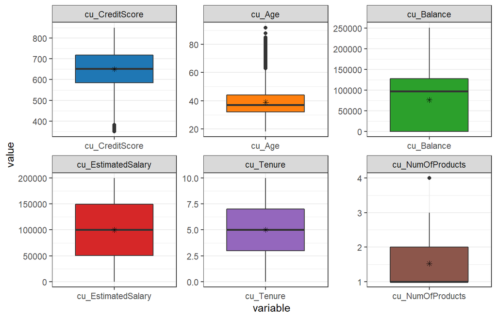

```r
## Grafica

##* Box
dat_long %>%
  ggplot(aes(variable, value,fill=variable))+
  geom_boxplot()+
  geom_point(data=dat_long %>%
               group_by(variable) %>%
               summarise(mean= mean(value)),
             aes(variable,mean), shape=8)+
  facet_wrap(.~variable, scales = "free")+
  theme_bw()+
  theme(legend.position='none')+
  scale_fill_d3()
```

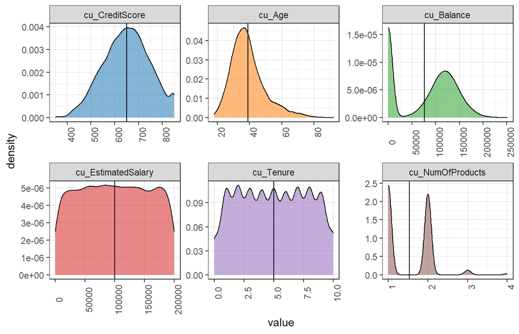

```r
##* Density
dat_long %>%
  select(variable,value) %>%
  ggplot(aes(value,group=variable,fill=variable, alpha=0.7))+
  geom_density(kernel = "gaussian")+

  geom_vline(data = dat_long %>%
               group_by(variable) %>%
               summarise(mean= mean(value)),
             aes(xintercept = mean))+
  facet_wrap(.~variable, scales = "free")+
  theme_bw()+
  theme(legend.position='none',axis.text.x = element_text(angle = 90))+
  scale_fill_d3()
```

```r
##* Tablas

dat %>%
  select(starts_with("cu")) %>%
  describe()
```

```
##                    vars     n      mean       sd    median   trimmed      mad
## cu_CreditScore        1 10000    650.53    96.65    652.00    651.01    99.33
## cu_Age                2 10000     38.92    10.49     37.00     37.91     8.90
## cu_Balance            3 10000  76485.89 62397.41  97198.54  74827.80 69336.44
## cu_EstimatedSalary    4 10000 100090.24 57510.49 100193.91 100114.86 72941.18
## cu_Tenure             5 10000      5.01     2.89      5.00      5.01     2.97
## cu_NumOfProducts      6 10000      1.53     0.58      1.00      1.49     0.00
##                       min      max    range  skew kurtosis     se
## cu_CreditScore     350.00    850.0    500.0 -0.07    -0.43   0.97
## cu_Age              18.00     92.0     74.0  1.01     1.39   0.10
## cu_Balance           0.00 250898.1 250898.1 -0.14    -1.49 623.97
## cu_EstimatedSalary  11.58 199992.5 199980.9  0.00    -1.18 575.10
## cu_Tenure            0.00     10.0     10.0  0.01    -1.17   0.03
## cu_NumOfProducts     1.00      4.0      3.0  0.75     0.58   0.01
```

```r
dat %>%
  select(starts_with("cu")) %>%
  summary.data.frame()
```

```
##  cu_CreditScore      cu_Age        cu_Balance     cu_EstimatedSalary
##  Min.   :350.0   Min.   :18.00   Min.   :     0   Min.   :    11.58
##  1st Qu.:584.0   1st Qu.:32.00   1st Qu.:     0   1st Qu.: 51002.11
##  Median :652.0   Median :37.00   Median : 97199   Median :100193.91
##  Mean   :650.5   Mean   :38.92   Mean   : 76486   Mean   :100090.24
##  3rd Qu.:718.0   3rd Qu.:44.00   3rd Qu.:127644   3rd Qu.:149388.25
##  Max.   :850.0   Max.   :92.00   Max.   :250898   Max.   :199992.48
##    cu_Tenure      cu_NumOfProducts
##  Min.   : 0.000   Min.   :1.00
##  1st Qu.: 3.000   1st Qu.:1.00
##  Median : 5.000   Median :1.00
##  Mean   : 5.013   Mean   :1.53
##  3rd Qu.: 7.000   3rd Qu.:2.00
##  Max.   :10.000   Max.   :4.00
```

Para representar las variables cuantitativas, se ha seleccionado el grafico boxplot donde se observan los valores extremos, el rango desde el primer hasta el tercer cuartil, la mediana y se ha representado la media mediante un asterisco.

Por otra parte, se ha elegido utilizar gráficos de densidad para ver cómo se distribuyen los valores de cada variable y se ha representado la media con una línea vertical.

Para cada variable cuantitativa se evaluará normalidad. Para ello se usa el test Kolmogorov-Smirnov y métodos visuales mediante gráfico de densidad y QQ plot (o quantile-quantile plot) en cada caso:

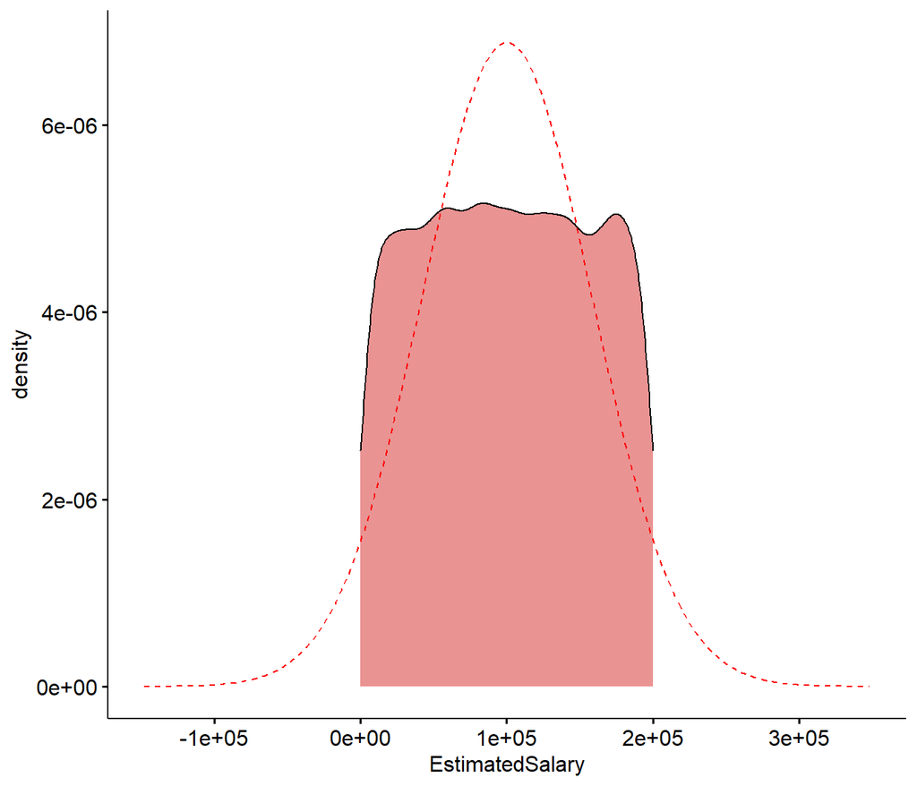

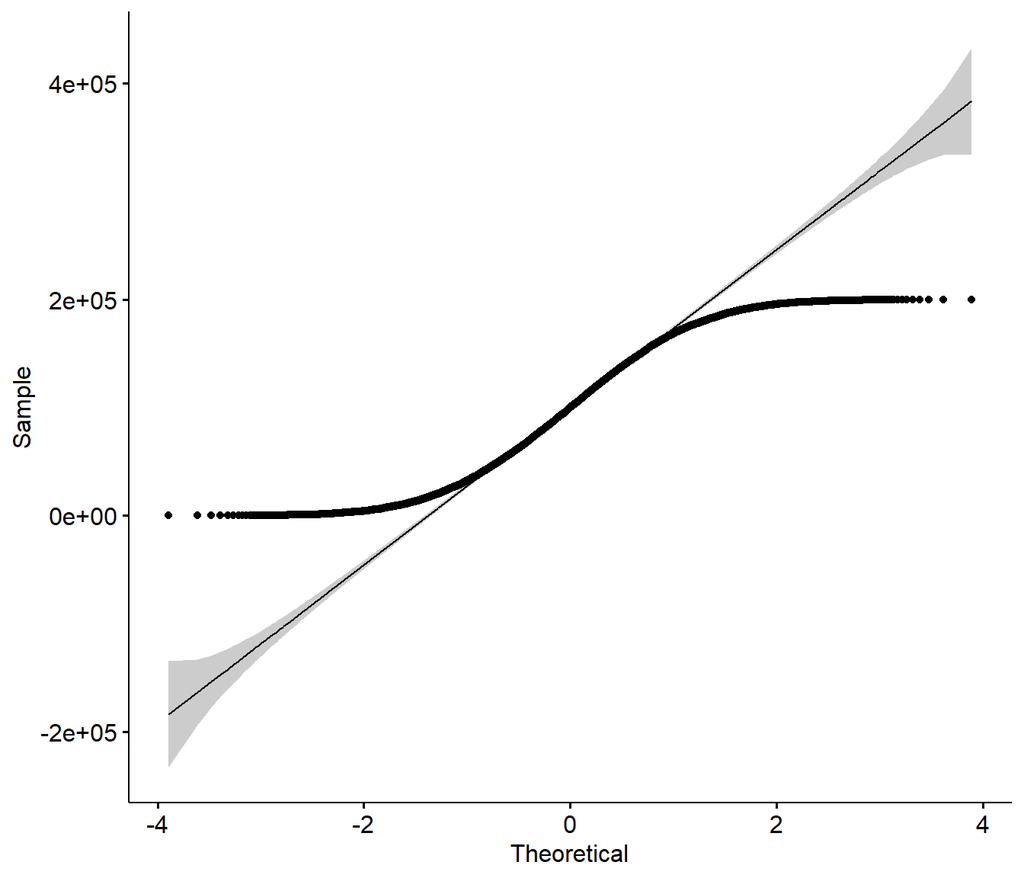

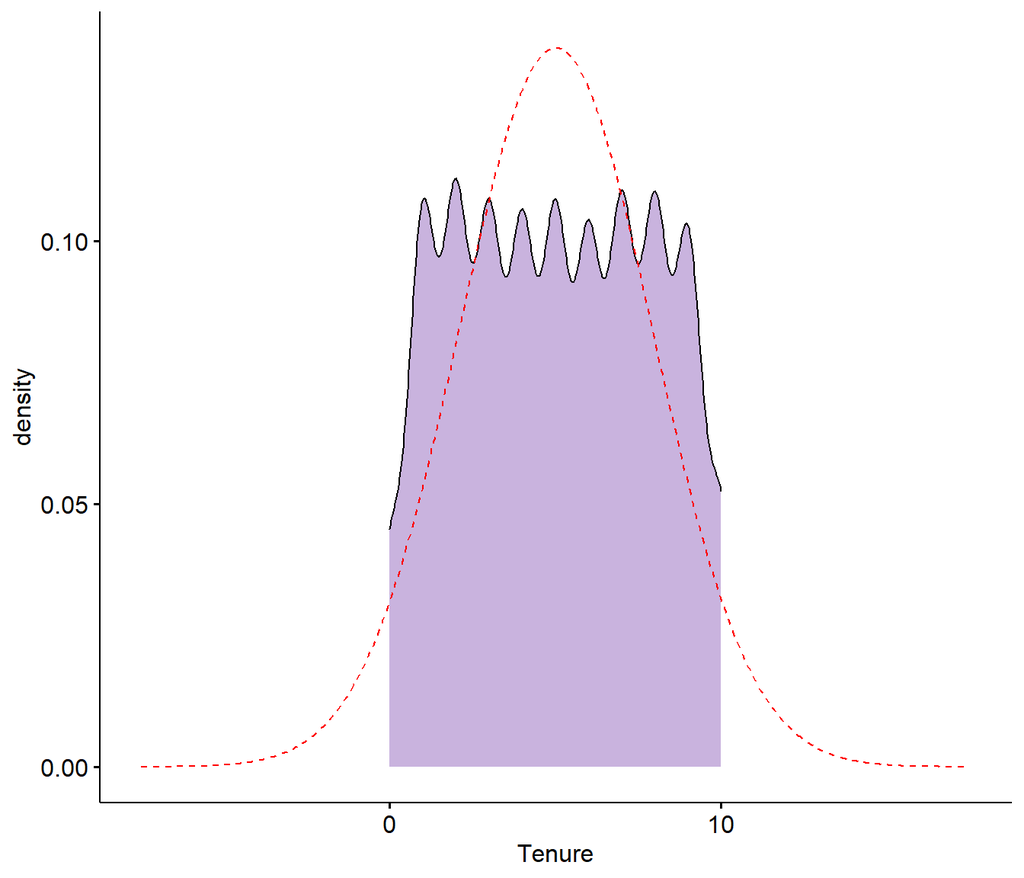

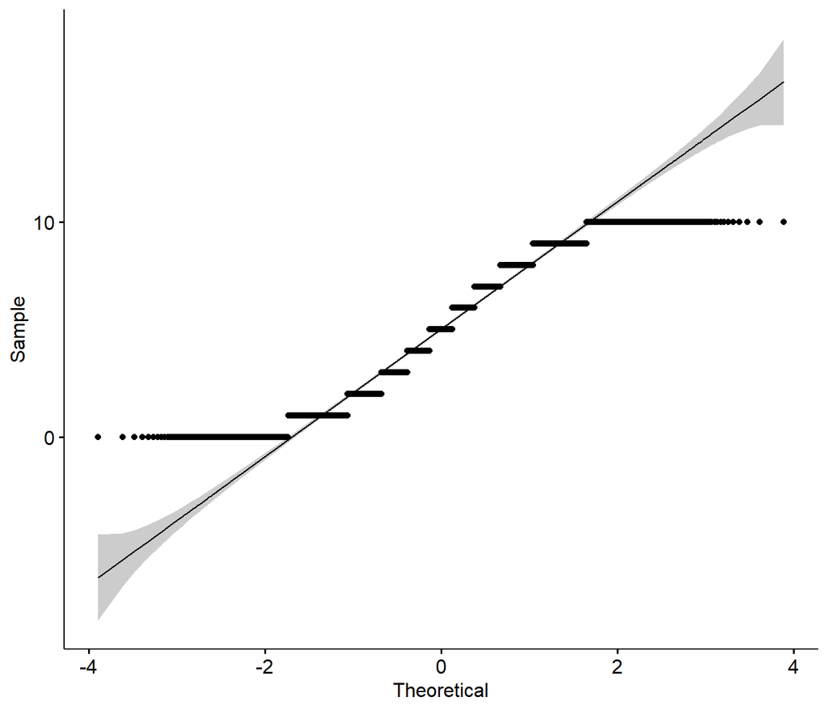

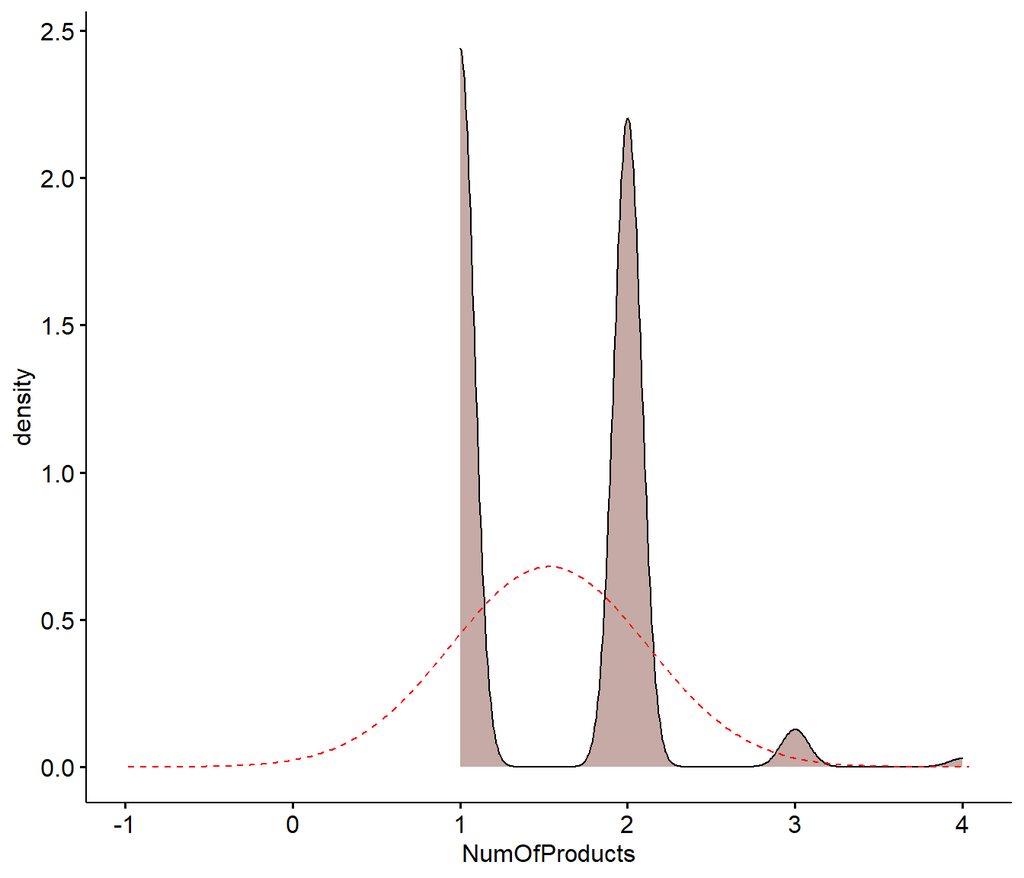

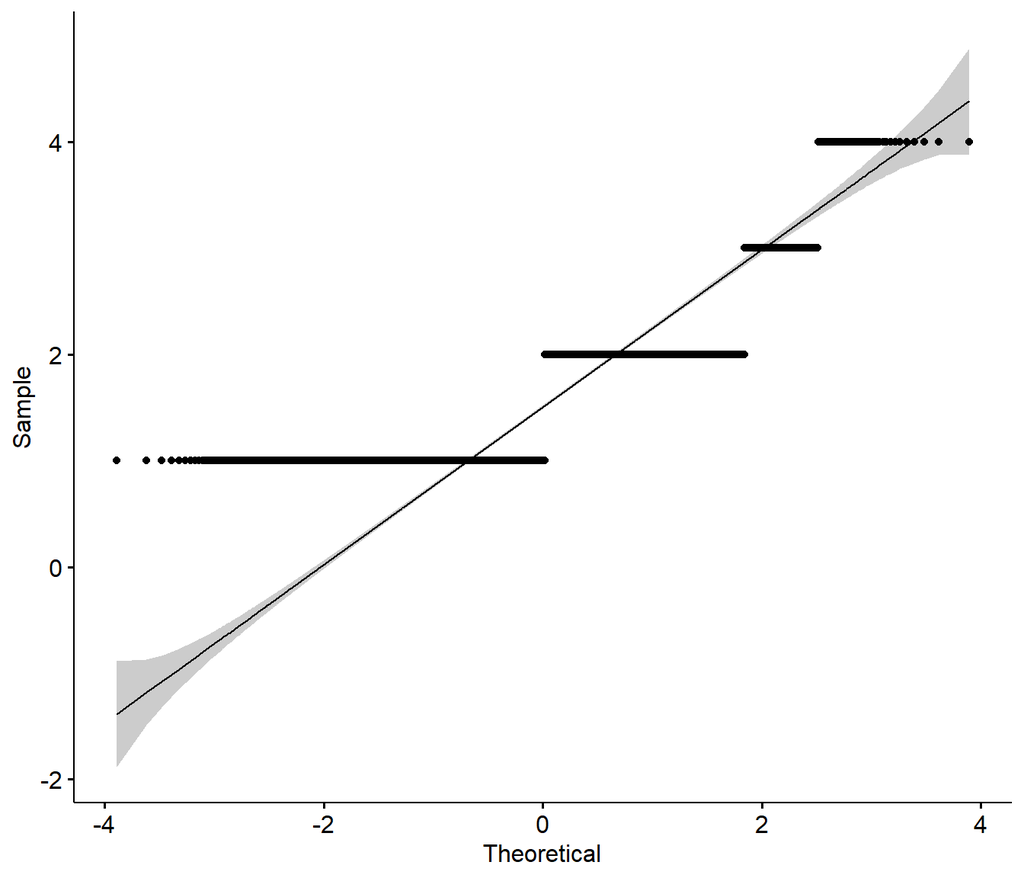

```r
##* cu_EstimatedSalary
g1 <- ggdensity(dat$cu_EstimatedSalary, fill = "#d62727")+
  stat_overlay_normal_density(color = "red", linetype = "dashed") +
  labs(x ="EstimatedSalary")
g2 <- ggqqplot(dat$cu_EstimatedSalary)
g1;g2

##* cu_Tenure
g1 <- ggdensity(dat$cu_Tenure, fill = "#9467bd")+
  stat_overlay_normal_density(color = "red", linetype = "dashed") +
  labs(x ="Tenure")
g2 <- ggqqplot(dat$cu_Tenure)
g1;g2

##* cu_NumOfProducts
g1 <- ggdensity(dat$cu_NumOfProducts, fill = "#8c564b")+
  stat_overlay_normal_density(color = "red", linetype = "dashed") +
  labs(x ="NumOfProducts")
g2 <- ggqqplot(dat$cu_NumOfProducts)
g1;g2
```

Para estos casos, es evidente que estas variables no siguen una distribución normal. Esto es esperado dada la naturaleza de `NumOfProducts` y `Tenure` al ser valores discretos y en el caso de `EstimatedSalary`, podría tratarse del modelo utilizado (supuesto).

En cuanto a las variables con aparente tendencia normal:

`CreditScore`

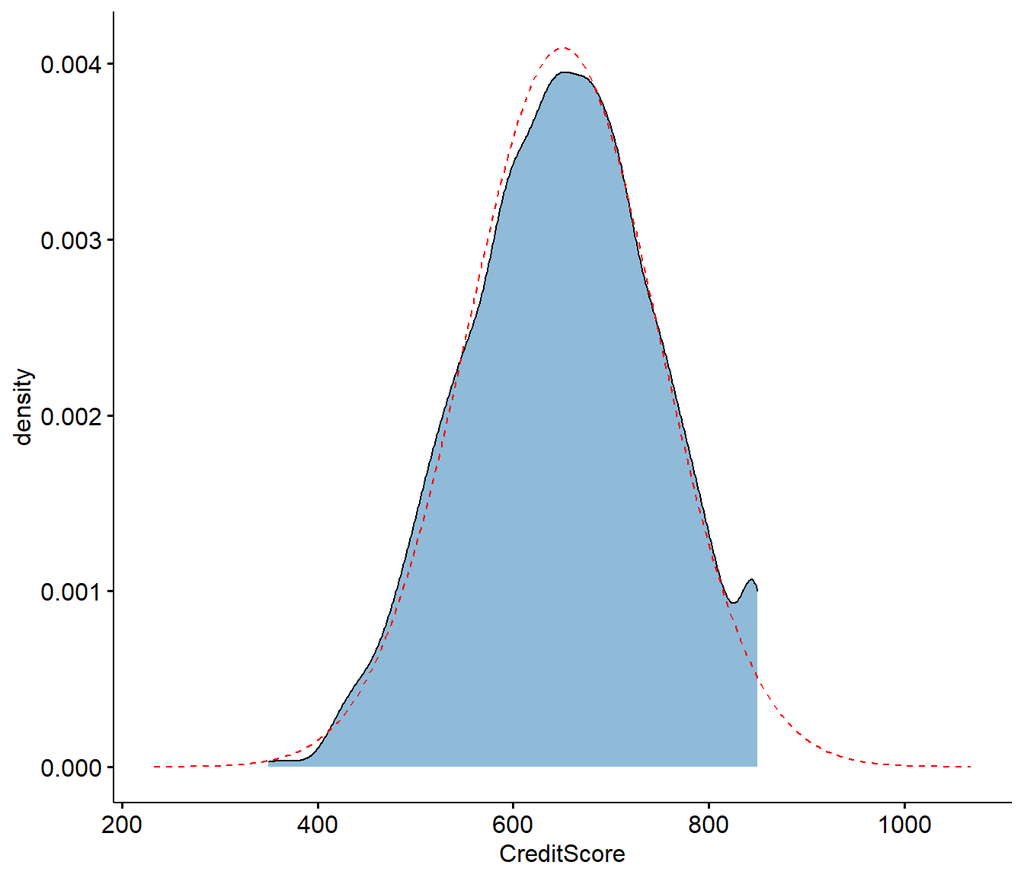

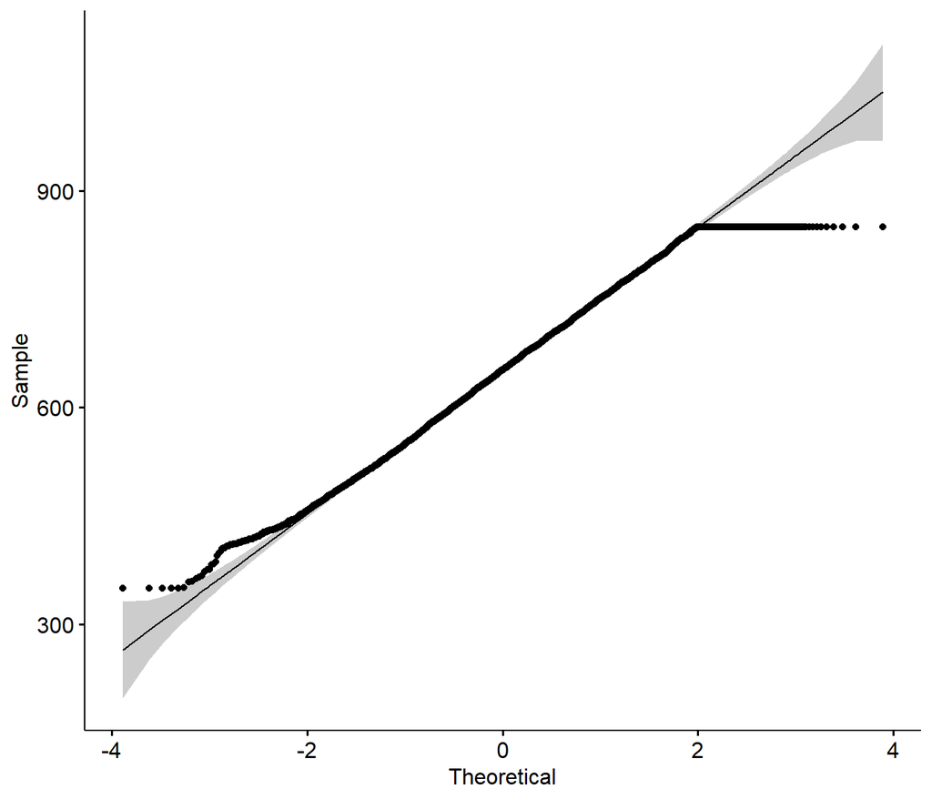

```r
##* cu_CreditScore:

g1 <- ggdensity(dat$cu_CreditScore, fill = "#1f77b4")+
  stat_overlay_normal_density(color = "red", linetype = "dashed")+
  labs(x ="CreditScore")
g2 <- ggqqplot(dat$cu_CreditScore)
g1;g2
```

`Age`:

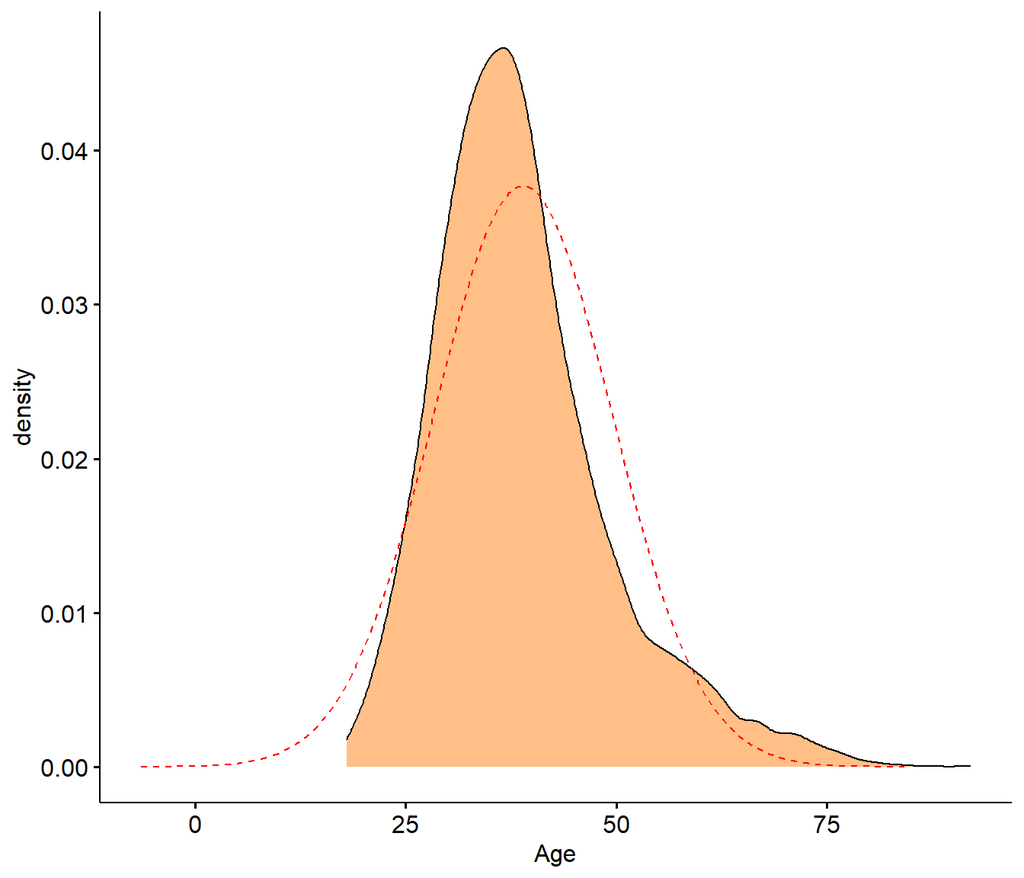

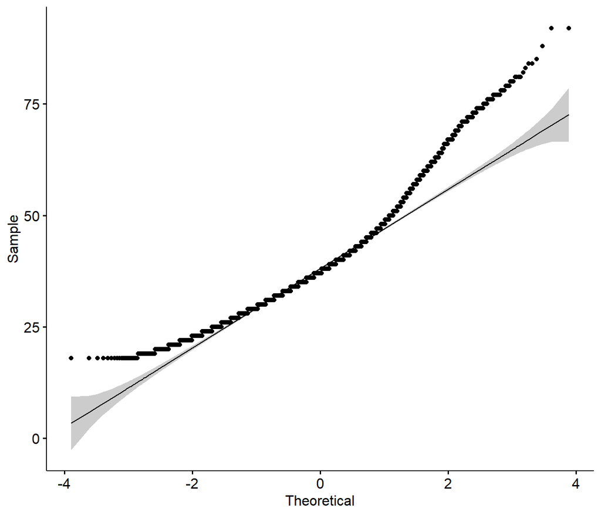

```r
##* cu_Age
g1 <- ggdensity(dat$cu_Age, fill = "#ff7f0e")+
  stat_overlay_normal_density(color = "red", linetype = "dashed")+
  labs(x ="Age")
g2 <- ggqqplot(dat$cu_Age)
g1;g2
```

`Balance`:

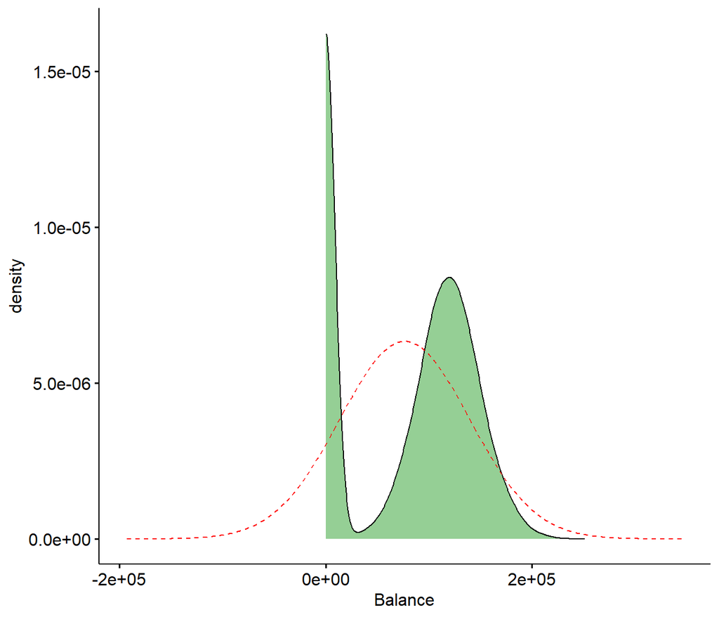

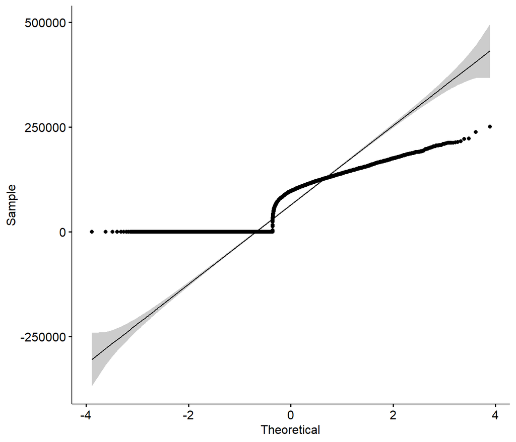

```r
##* cu_Balance
g1 <- ggdensity(dat$cu_Balance, fill = "#2ca02c")+
  stat_overlay_normal_density(color = "red", linetype = "dashed")+
  labs(x ="Balance")
g2 <- ggqqplot(dat$cu_Balance)
g1;g2
```

```r
##* Tabla
dat_long %>%
  select(variable,value) %>%
  group_by(variable) %>%
  summarise(mean= round(mean(value),2),
            sd= round(sd(value),2),
            ks_pval = ks.test(value,"pnorm")$p.value,
            ks_stat = round(ks.test(value,"pnorm")$statistic,2),
            count_outliers= length(boxplot(value)$out)
            )
```

```
## # A tibble: 6 x 6
##   variable                mean        sd ks_pval ks_stat count_outliers
##   <fct>                  <dbl>     <dbl>   <dbl>   <dbl>          <int>
## 1 cu_CreditScore        651.      96.6         0    1                15
## 2 cu_Age                 38.9     10.5         0    1               359
## 3 cu_Balance          76486.   62397.          0    0.64              0
## 4 cu_EstimatedSalary 100090.   57510.          0    1                 0
## 5 cu_Tenure               5.01     2.89        0    0.83              0
## 6 cu_NumOfProducts        1.53     0.580       0    0.84             60
```

El test, en todos los casos, nos muestra un P.value muy cercano a 0, indicando que se descarta la H<sub>0</sub> y no seguirían una distribución normal (en función del análisis, sería necesaria una transformación previa.). Sin embargo, para el caso de `Age`, es posible que los outliers evidenciados influyan, por lo que se decide realizar el análisis removiéndolos:

```r
##* cu_Age

##* Para identificar outliers y removerlos (la gráfica previa nos permite identificar
##* Que solo existen outliers superiores, por lo que se puede filtrar respecto al menor
##* de ellos):
out <- as.numeric(min (boxplot(dat$cu_Age)$out) )
```

```r
out <-dat %>%
  filter(cu_Age < out)
```

[output not shown]

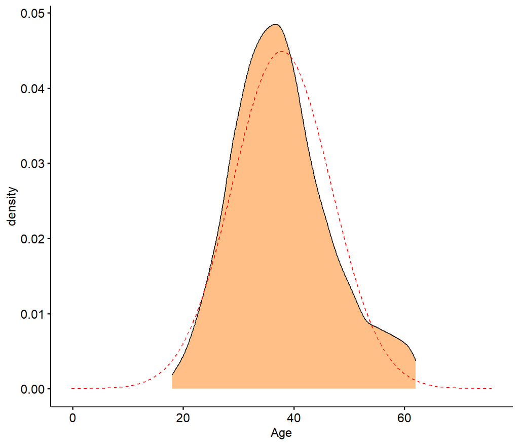

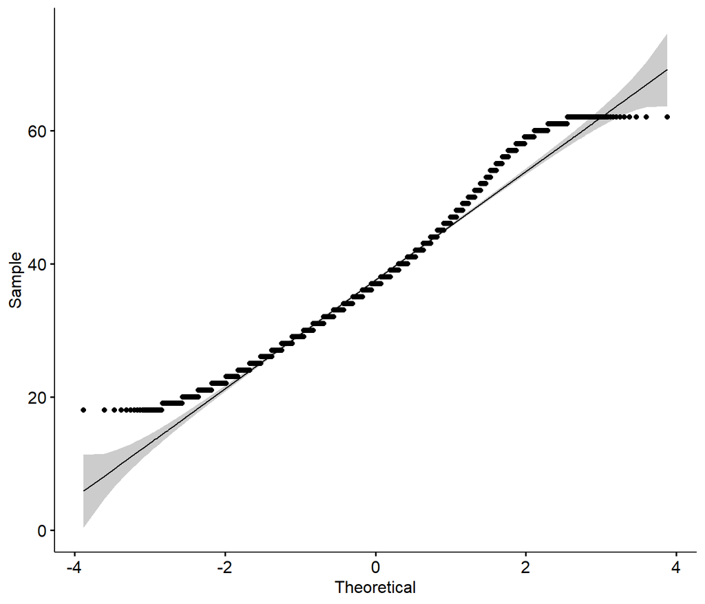

```r
g1 <- ggdensity(out$cu_Age, fill = "#ff7f0e")+
  stat_overlay_normal_density(color = "red", linetype = "dashed")+
  labs(x ="Age")
g2 <- ggqqplot(out$cu_Age)
g1;g2

ks.test(out$cu_Age,"pnorm")
```

Si bien gráficamente se pudiera manejar como normal, el test nos indica nuevamente que se rechaza H<sub>0</sub>, por lo que existe un 95% de certeza de que la distribución de la variable `Age` no sigue una distribución normal.

## **3. Análisis estadístico**

##### **Realizar un análisis de comparación, siendo la hipótesis inicial: El salario de los consumidores es igual en los diferentes países donde se han recogido los datos**

H<sub>0</sub>=El salario de los consumidores es igual en los diferentes países donde se han recogido los datos.

H<sub>a</sub>=El salario de los consumidores no es igual en los diferentes países donde se han recogido los datos.

Para ello, inicialmente se comparan visualmente y por dato las medias agrupadas por `Geography`

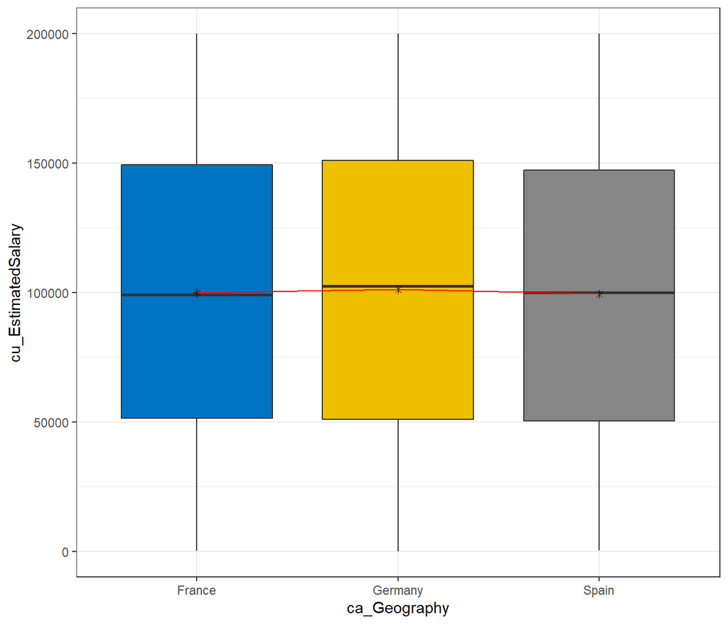

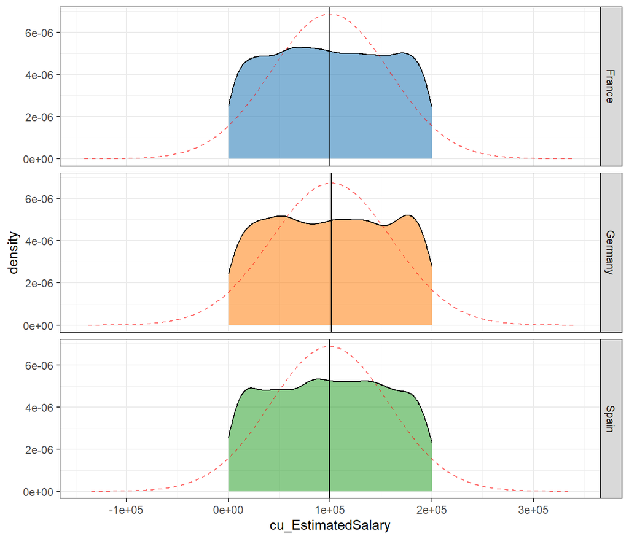

```r
medias<-dat %>%
  select(ca_Geography,cu_EstimatedSalary) %>%
  group_by(ca_Geography) %>%
  summarise(mean=mean(cu_EstimatedSalary))

ggplot(dat, aes(ca_Geography,cu_EstimatedSalary,fill=ca_Geography))+
  geom_boxplot()+
  geom_point(data=medias,aes(ca_Geography,mean),shape=8)+
  geom_line(data=medias,aes(ca_Geography,mean), group=1, color="red")+
  theme_bw()+
  theme(legend.position='none')+
  scale_fill_jco()

dat %>%
  ggplot(aes(cu_EstimatedSalary, fill = ca_Geography, alpha=0.9)) +
  geom_density(kernel = "gaussian") +
  geom_vline(data = dat %>%
               group_by(ca_Geography) %>%
               summarise(mean= mean(cu_EstimatedSalary)),
             aes(xintercept = mean))+
  stat_overlay_normal_density(color = "red", linetype = "dashed")+
  theme_bw()+
  facet_grid(ca_Geography~.)+
  theme(legend.position='none')+
  scale_fill_d3()
```

Visualmente no se identifica mucha variación. Esto era de esperarse luego de ver previamente que la variable distribución de `EstimatedSalary` era uniforme.

Sin embargo, se procede con la confirmación mediante test estadístico. Dado que se trata de 1 variable cuantitativa y 1 categórica de más de 2 niveles, se decide realizar el test anova:

```r
anova(lm(dat$cu_EstimatedSalary~dat$ca_Geography))
```

```
## Analysis of Variance Table
##
## Response: dat$cu_EstimatedSalary
##                    Df     Sum Sq    Mean Sq F value Pr(>F)
## dat$ca_Geography    2 3.8552e+09 1927617402  0.5828 0.5584
## Residuals        9997 3.3067e+13 3307732835
```

Según el análisis anova, el p-value es de 0.5584, al ser mayor a 0.05, no se rechaza la hipótesis nula H<sub>0</sub>, por tanto, la diferencia del salario no es significativamente diferente entre los países, hecho que se ve apoyado con la inspección grafica previa.